# USP 634 Lab 5- Hypothesis Testing

Jamaal Green and Liming Wang

```r
library(tidyverse)

#set your working directory
californiatod <- read_csv("californiatod.csv")
```

# 1 QQ Plot

Recall that superimposed a normal curve on top of a histogram to get a rough idea of whether a variable is normally distributed.

First, we will create a histogram for density and superimpose a curve on top of it.

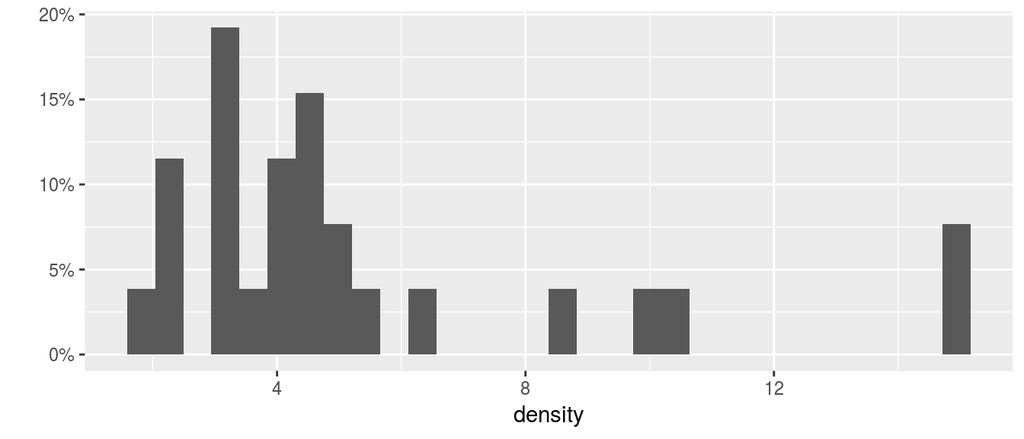

```r
library(scales)
# show percentage
hist.percent <- ggplot(californiatod, aes(x=density)) +
        geom_histogram(aes(y=(..count..)/sum(..count..))) +
        scale_y_continuous(labels=percent) + labs(y="")
hist.percent
```

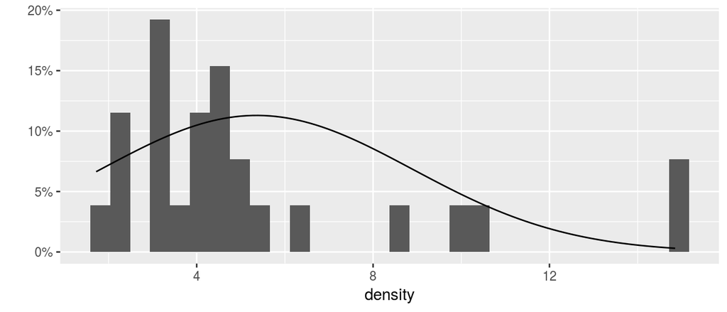

```r
# with normal curve superimposed
hist.percent + stat_function(fun=dnorm, args=list(mean=mean(californiatod$density),
                                                  sd=sd(californiatod$density)))
```

There are better ways to do this. One way to determine if a variable is normally distributed is to use a QQ plot. You can use the **geom_qq** function to create a Quantile-Quantile plot evaluating the fit of a sample data to a normal distribution. More generally, the **geom_qq(distribution=q)** function creates a Quantile-Quantile plot for any theoretical distribution, **geom_qq_line()** draws a diagonal line for the fit of a theoretical distribution.

Let’s create a qqplot for the density and house value variables:

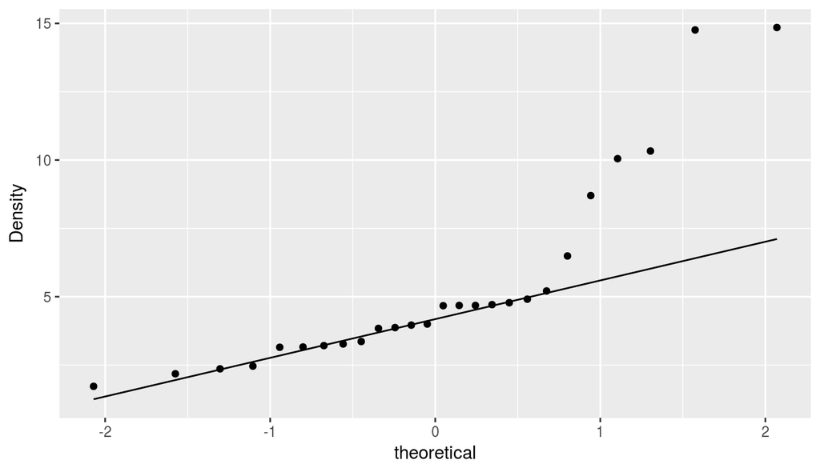

```r
ggplot(californiatod, aes(sample=density)) +
  geom_qq() + geom_qq_line() + ylab("Density")
```

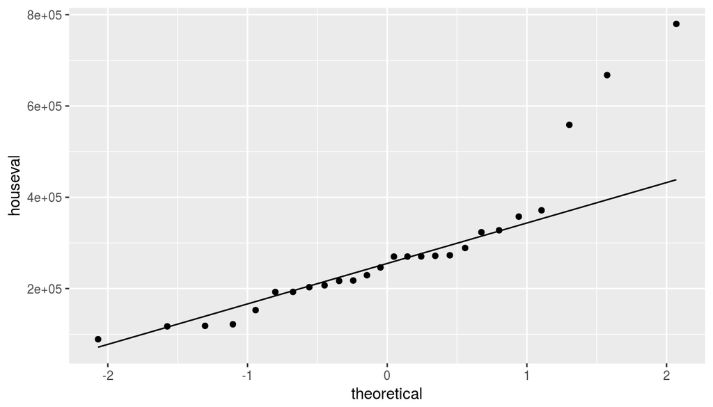

```r
ggplot(californiatod, aes(sample=houseval)) +
  geom_qq() + geom_qq_line() + ylab("houseval")
```

Which of these two variables are more likely to be normally distributed?

# 2 A quick tutorial for visualization with ggplot2

`ggplot2` is a grammar of graphics, a coherent system for describing and building graphs.

- **data (data frame): ggplot(dataset)**
- **aesthetic mapping (coordination system, color, size, line type, position etc): aes()**
- **geometries: geom_point, geom_line, geom_bar, …**
- stat (summarization/transformation of data): stat_smooth,
- scale (map data values into computer values): scale_y_continuous(labels=percent), scale_x_log10, …
- facet: facet_wrap, facet_grid
- fine tuning
  - coordinate: `coordinate_*`
  - theme: `theme_bw`
  - labels: `labs(x=..., y=...)`

And you can add layers to your graph with `+`. See how we plot our histogram and add the normal curve on top of it

```r
hist.percent <- ggplot(californiatod, aes(x=density)) +
        geom_histogram(aes(y=(..count..)/sum(..count..))) +
        scale_y_continuous(labels=percent) + labs(y="")

hist.percent + stat_function(fun=dnorm, args=list(mean=mean(californiatod$density),
                                                  sd=sd(californiatod$density)))
```

[output not shown]

## 2.1 Learning more

- Wickham’s [R4DS Chapter 3: Data Visualization](http://r4ds.had.co.nz/data-visualisation.html)
- [ggplot2 cheatsheet](https://www.rstudio.com/wp-content/uploads/2015/03/ggplot2-cheatsheet.pdf)
- [ggplot2 cookbook](http://www.cookbook-r.com/Graphs/)

# 3 t-tests

## 3.1 Conduct single sample hypothesis test by hand

We will now compute a **single sample hypothesis test** with a known mean by hand. We shall test whether the mean housing value in the TOD dataset is statistically significantly different from the mean of all housing on the market (assuming mean = 250000).

The formular R uses for computing the test statistic is:

$$\frac{\bar{x} - \mu}{\frac{s}{\sqrt{n-1}}}$$

1. Find the mean and standard deviation of the variable houseval:

```r
xbar <- mean(californiatod$houseval)
mu <- 250000
s <- sd(californiatod$houseval)
n <- nrow(californiatod)
```

2. Now use R as a calculator to compute the t-statistic by hand. Enter the correct numerical values to compute this statement:

`(sample_mean - population_mean)/(sample_sd/(square_root(n-1)))`

Replace each term with the correct corresponding numerical value. Note that to designate a square root you can use **sqrt()**.

```r
tstar <- (xbar - mu)/(s/sqrt(n-1))
tstar
```

```
## [1] 0.9857827
```

3. You can get the p-value with

```r
p <- 2*pt(-abs(tstar), df = n-1)
p
```

```
## [1] 0.3336849
```

Question: What is the null hypothesis for this test? Should you reject the null hypothesis based on the p-value?

## 3.2 Compute the single sample t-test in R.

```r
t.test(californiatod$houseval, alternative = 'two.sided', mu = 250000, conf.level = .95)
```

```
##
##  One Sample t-test
##
## data:  californiatod$houseval
## t = 1.0053, df = 25, p-value = 0.3244
## alternative hypothesis: true mean is not equal to 250000
## 95 percent confidence interval:
##  216280.3 348029.1
## sample estimates:
## mean of x
##  282154.7
```

Compare the results to our hand calculations.

## 3.3 Conduct a group-mean t-test manually

The formula R uses for computing the test statistics is:

$$\frac{\bar{x_{1}} - \bar{x_{2}}}{\sqrt{\frac{s^2_{1}}{n_{1}}+ \frac{s^2_{2}}{n_2}}}$$

1. Find the mean and standard deviation for the variable houseval

```r
xbar1 <- with(californiatod, mean(houseval[railtype == "Light rail"]))

xbar2 <- with(californiatod, mean(houseval[railtype == "Heavy or commuter rail"]))

s1 <- with(californiatod, sd(houseval[railtype == "Light rail"]))

s2 <- with(californiatod, sd(houseval[railtype == "Heavy or commuter rail"]))

n1 <- with(californiatod, length(houseval[railtype == "Light rail"]))

n2 <- with(californiatod, length(houseval[railtype == "Heavy or commuter rail"]))
```

2. Now use R as a calculator to compute the t-statistic by hand. Enter the correct numerical values to complete the formula:

$$\frac{\bar{x_{1}} - \bar{x_{2}}}{\sqrt{\frac{s^2_{1}}{n_{1}}+ \frac{s^2_{2}}{n_2}}}$$

Replace each term with the correct corresponding numerical value. Note that to designate a square root use the **sqrt()** function.

```r
tstar <- (xbar1 - xbar2)/ sqrt(s1^2/n1 + s2^2/n2)
tstar
```

```
## [1] -3.408729
```

3. You can get the p-value for the two-sided test with

```r
p <- 2*pt(-abs(tstar), df =  pmin(n1, n2)-1)
p
```

```
## [1] 0.009240479
```

Theoretically the formula is not exactly appropriate for our small sample size, but for now it shall suffice. You can use this same equation for calculating the p-value in Assignment 2.

## 3.4 Compute the group means t-test with R

The general syntax for the t-test in R is

> t.test(var1 ~ var2, data)

In this var1 is a continuous variable and var2 is a categorical variable.

Execute the test by placing the proper variable names into the generic command (in this case *houseval* and *railtype*)

```r
t.test(houseval ~ railtype, data = californiatod)
```

```
##
##  Welch Two Sample t-test
##
## data:  houseval by railtype
## t = 3.4087, df = 23.927, p-value = 0.002314
## alternative hypothesis: true difference in means is not equal to 0
## 95 percent confidence interval:
##   65647.09 267225.93
## sample estimates:
## mean in group Heavy or commuter rail             mean in group Light rail
##                             339767.3                             173330.8
```

Can we reject the null hypothesis given these results?

## 3.5 Two-sided versus one-sided

```r
#Default t.test()
t.test(houseval ~ railtype, data = californiatod, alternative = 'two.sided', conf.level = .95)
```

```
##
##  Welch Two Sample t-test
##
## data:  houseval by railtype
## t = 3.4087, df = 23.927, p-value = 0.002314
## alternative hypothesis: true difference in means is not equal to 0
## 95 percent confidence interval:
##   65647.09 267225.93
## sample estimates:
## mean in group Heavy or commuter rail             mean in group Light rail
##                             339767.3                             173330.8
```

```r
#one sided t.test()

t.test(houseval ~ railtype, data = californiatod, alternative = 'greater', conf.level = .95)
```

```
##
##  Welch Two Sample t-test
##
## data:  houseval by railtype
## t = 3.4087, df = 23.927, p-value = 0.001157
## alternative hypothesis: true difference in means is greater than 0
## 95 percent confidence interval:
##  82889.75      Inf
## sample estimates:
## mean in group Heavy or commuter rail             mean in group Light rail
##                             339767.3                             173330.8
```

In order to get the p-value for one-sided t distribution

> pt(-abs(tstar), df = length(californiatod) - 1)

## 3.6 Paired t-test

The general form of the syntax is:

> t.test(var1, var2, data = Dataset, alternative = ‘two.sided’, conf.level = .95, paired = TRUE)

This is the type of t-test you want to conduct for Question 4 in Assigment 2.